# Transparent Conductors Predictions

> **John El Berch**

# Exploratory Data Analysis (EDA)

### Executive Summary

This notebook starts with defining preprocessing features, and with some background on the project. Individual notebooks are available for preliminar information, as well as visualizations based on both the original and the preprocessed inputs.

#### Why this project?

This application aligns well with my Ph.D.'s research topic (computational catalysis) and, beyond the learning experience, I believe it would be great to feature this project as part of my digital portfolio.

#### Experience

My experience with the topic comes from my Ph.D. research, focused on the discovery of novel catalysts through computational chemistry. Although this application (focused on semiconductor discovery) doesn't exactly match my research area, many concepts are shared (specially, those related to material properties). As a newcomer in the data science field (starting in CMPINF 2100 last semester), I haven't worked on a data-based project for an application similar to this.

#### Goals

Predict two target properties (Formation energy and Bandgap energy) for promising transparent conductors based on material properties such as the spacegroup, total number of atoms, relative compositions...

#### References and resources

Project based on [Kaggle](https://www.kaggle.com/competitions/nomad2018-predict-transparent-conductors/rules) competition. For the project, two data sets were provided, a `train.csv` and a hold-out `test.csv` dataset. Both are available in the provided link upon agreeing to the competitions' rules. Both datasets will be explored, while the `train.csv` will be used to test for different models' effectiveness. A separate `submission.csv` file will be available at the main GitHub, which will contain all the predicted values as:

```
id,formation_energy_ev_natom,bandgap_energy_ev
1,0.1779,1.8892
2,0.1779,1.8892
3,0.1779,1.8892
...
```

Finally, a `score.txt` file will be submitted with the score obtained from Kaggle.

## Load modules, data, and generate relevant features

### Import modules

```python
import pandas as pd
import numpy as np
import matplotlib.pyplot as plt
import seaborn as sns
```

### Read the training and testing data sets

##### `train.csv`

```python
df_train = pd.read_csv('../train.csv')
df_train.head()
```

|  | id | spacegroup | number_of_total_atoms | percent_atom_al | percent_atom_ga | percent_atom_in | lattice_vector_1_ang | lattice_vector_2_ang | lattice_vector_3_ang | lattice_angle_alpha_degree | lattice_angle_beta_degree | lattice_angle_gamma_degree | formation_energy_ev_natom | bandgap_energy_ev |
| --- | --- | --- | --- | --- | --- | --- | --- | --- | --- | --- | --- | --- | --- | --- |
| 0 | 1 | 33 | 80.0 | 0.6250 | 0.3750 | 0.000 | 9.9523 | 8.5513 | 9.1775 | 90.0026 | 90.0023 | 90.0017 | 0.0680 | 3.4387 |
| 1 | 2 | 194 | 80.0 | 0.6250 | 0.3750 | 0.000 | 6.1840 | 6.1838 | 23.6287 | 90.0186 | 89.9980 | 120.0025 | 0.2490 | 2.9210 |
| 2 | 3 | 227 | 40.0 | 0.8125 | 0.1875 | 0.000 | 9.7510 | 5.6595 | 13.9630 | 90.9688 | 91.1228 | 30.5185 | 0.1821 | 2.7438 |
| 3 | 4 | 167 | 30.0 | 0.7500 | 0.0000 | 0.250 | 5.0036 | 5.0034 | 13.5318 | 89.9888 | 90.0119 | 120.0017 | 0.2172 | 3.3492 |
| 4 | 5 | 194 | 80.0 | 0.0000 | 0.6250 | 0.375 | 6.6614 | 6.6612 | 24.5813 | 89.9960 | 90.0006 | 119.9893 | 0.0505 | 1.3793 |

##### `test.csv`

```python
df_test = pd.read_csv('../test.csv')
df_test.head()
```

|  | id | spacegroup | number_of_total_atoms | percent_atom_al | percent_atom_ga | percent_atom_in | lattice_vector_1_ang | lattice_vector_2_ang | lattice_vector_3_ang | lattice_angle_alpha_degree | lattice_angle_beta_degree | lattice_angle_gamma_degree |
| --- | --- | --- | --- | --- | --- | --- | --- | --- | --- | --- | --- | --- |
| 0 | 1 | 33 | 80.0 | 0.1875 | 0.4688 | 0.3438 | 10.5381 | 9.0141 | 9.6361 | 89.9997 | 90.0003 | 90.0006 |
| 1 | 2 | 33 | 80.0 | 0.7500 | 0.2500 | 0.0000 | 9.8938 | 8.5014 | 9.1298 | 90.0038 | 90.0023 | 90.0015 |
| 2 | 3 | 167 | 30.0 | 0.6667 | 0.1667 | 0.1667 | 4.9811 | 4.9808 | 13.4799 | 89.9900 | 90.0109 | 120.0014 |
| 3 | 4 | 12 | 80.0 | 0.5625 | 0.4375 | 0.0000 | 24.3370 | 6.0091 | 5.7620 | 89.9995 | 103.8581 | 90.0002 |
| 4 | 5 | 12 | 80.0 | 0.1875 | 0.5000 | 0.3125 | 24.6443 | 6.2906 | 6.1589 | 90.0000 | 104.5929 | 90.0001 |

→ Treat the `spacegroup` variable as a categorical. Create a categorical version of the `number_of_total_atoms` and also create an additional categorical variable splitting the `number_of_atoms` variable as 80 or other.

```python
df_train['spacegroup'] = df_train['spacegroup'].astype('category')
df_train['number_of_total_atoms_cat'] = df_train['number_of_total_atoms'].astype('category')
df_train['binary_number_of_total_atoms'] = np.where(df_train.number_of_total_atoms.to_numpy() == 80, '80', 'other')
```

```python
df_test['spacegroup'] = df_test['spacegroup'].astype('category')
df_test['number_of_total_atoms_cat'] = df_test['number_of_total_atoms'].astype('category')
df_test['binary_number_of_total_atoms'] = np.where(df_test.number_of_total_atoms.to_numpy() == 80, '80', 'other')
```

### Create new preprocessed features

New Variable 1: Deviations from ideal spacegroup data

```python
Spacegroup_df = pd.DataFrame({'alpha_theory' : [90, 90, 90, 90, 90, 90],
                             'gamma_theory' : [90, 90, 90, 120, 90, 120] ,
                            'spacegroup' : [206, 33, 227, 167, 12, 194]})
```

```python
prepro_df_train = pd.merge(left=Spacegroup_df,right=df_train.copy(), how='inner', on='spacegroup')
prepro_df_test = pd.merge(left=Spacegroup_df,right=df_test.copy(), how='inner', on='spacegroup')
```

```python
prepro_df_train['alpha_comparisson'] = prepro_df_train['lattice_angle_alpha_degree'] - prepro_df_train['alpha_theory']
prepro_df_train['gamma_comparisson'] = prepro_df_train['lattice_angle_gamma_degree'] - prepro_df_train['gamma_theory']
prepro_df_test['alpha_comparisson'] = prepro_df_test['lattice_angle_alpha_degree'] - prepro_df_test['alpha_theory']
prepro_df_test['gamma_comparisson'] = prepro_df_test['lattice_angle_gamma_degree'] - prepro_df_test['gamma_theory']
```

Create sigmoid feature

```python
def sigmoid(x):
    return np.exp(x) / (np.exp(x)+1) - 0.5
```

```python
prepro_df_train['alpha_sigmoid'] = sigmoid(prepro_df_train['alpha_comparisson'])
prepro_df_train['gamma_sigmoid'] = sigmoid(prepro_df_train['gamma_comparisson'])
prepro_df_test['alpha_sigmoid'] = sigmoid(prepro_df_test['alpha_comparisson'])
prepro_df_test['gamma_sigmoid'] = sigmoid(prepro_df_test['gamma_comparisson'])
```

Variable 2: Proportions between lattice constants

```python
prepro_df_train['a_to_b'] = prepro_df_train.lattice_vector_1_ang.to_numpy() / prepro_df_train.lattice_vector_2_ang.to_numpy()
prepro_df_test['a_to_b'] = prepro_df_test.lattice_vector_1_ang.to_numpy() / prepro_df_test.lattice_vector_2_ang.to_numpy()
```

```python
prepro_df_train['a_to_c'] = prepro_df_train.lattice_vector_1_ang.to_numpy() / prepro_df_train.lattice_vector_3_ang.to_numpy()
prepro_df_test['a_to_c'] = prepro_df_test.lattice_vector_1_ang.to_numpy() / prepro_df_test.lattice_vector_3_ang.to_numpy()
```

New Variable 3: Logit transformation of percentages

```python
'percent_atom_'

for element in ['al','ga','in']:
    for df in [prepro_df_test, prepro_df_train]:
        P = (df['percent_atom_'+element].to_numpy() - -0.01) / (1.02)
        OR = P / (1-P)
        df['logit_'+element] = np.log(OR)
```

New Variable 4: Log transformation of Bandgap energy

```python
prepro_df_train['log_bandgap'] = np.log(prepro_df_train.bandgap_energy_ev.to_numpy())
```

### Define helping lists of inputs, outputs and categorical variables

Original Features

```python
output_list = ['formation_energy_ev_natom', 'bandgap_energy_ev']
categorical_list = ['spacegroup','number_of_total_atoms_cat','binary_number_of_total_atoms']
input_list = [var for var in df_train.columns.to_list() if var not in output_list+categorical_list+['id','number_of_total_atoms']]
```

Preprocessed Features

```python
prepro_output_list = ['formation_energy_ev_natom', 'log_bandgap']
prepro_categorical_list = ['spacegroup','number_of_total_atoms_cat','binary_number_of_total_atoms']

Exclude_List = ['alpha_theory', 'gamma_theory', 'id', 'number_of_total_atoms', 'percent_atom_al', 'percent_atom_in', 'percent_atom_ga',
                 'alpha_comparisson', 'gamma_comparisson', 'bandgap_energy_ev']

prepro_input_list = [var for var in prepro_df_train.columns.to_list() if var not in prepro_output_list+prepro_categorical_list+Exclude_List]

prepro_features_list = ['logit_al','logit_ga','logit_in','a_to_b','a_to_c','alpha_sigmoid','gamma_sigmoid']
```

Colors

```python
c_train = list(np.array([0,190,255,255])/255)
c_test = list(np.array([181,29,20,255])/255)
```

## Counts on Categorical Variables

**Overall take-home:** the proportions of categorical inputs are similar between the `train.csv` and `test.csv`

#### Spacegroup

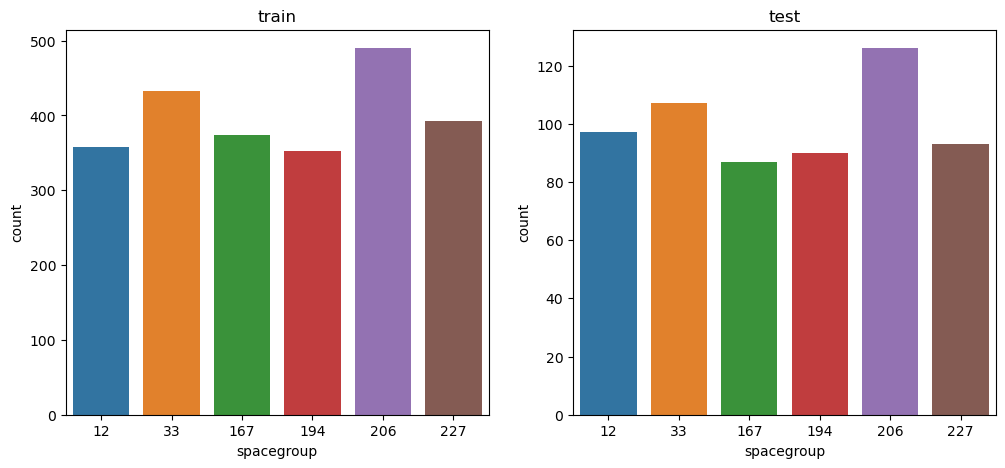

```python
fig, ax = plt.subplots(1,2,figsize=(12,5))

sns.countplot(data=df_train, x='spacegroup', ax=ax[0]).set(title='train')
sns.countplot(data=df_test, x='spacegroup', ax=ax[1]).set(title='test')

plt.show()
```

> Take-home: There's a similar number of observations per spacegroup type on both `train.csv` and `test.csv`

#### Number of total atoms

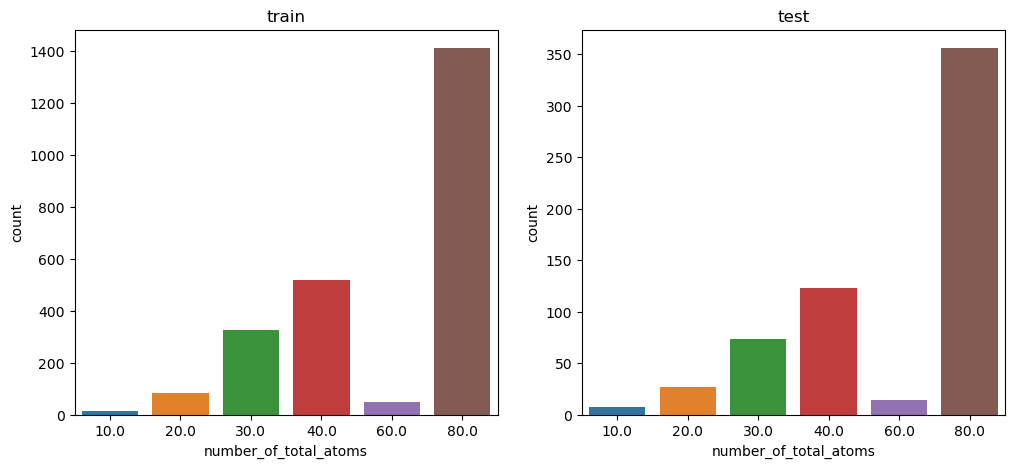

```python
fig, ax = plt.subplots(1,2,figsize=(12,5))

sns.countplot(data=df_train, x='number_of_total_atoms', ax=ax[0]).set(title='train')
sns.countplot(data=df_test, x='number_of_total_atoms', ax=ax[1]).set(title='test')

plt.show()
```

> Take-home: There's a larger number of crystals with 80 atoms. Although the proportions are similar between the `train.csv` and `test.csv`, the number of observations per `number_of_total_atoms` varies significantly. These led to the suggestion of using a *binarized number_of_total_atoms* variable, explored next

#### Binarized model of number of atoms

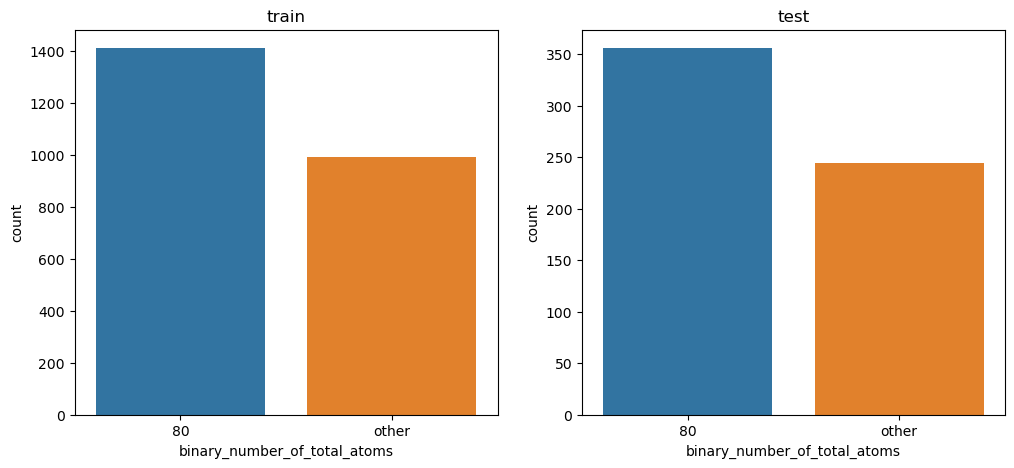

```python
fig, ax = plt.subplots(1,2,figsize=(12,5))

sns.countplot(data=df_train, x='binary_number_of_total_atoms', ax=ax[0]).set(title='train')
sns.countplot(data=df_test, x='binary_number_of_total_atoms', ax=ax[1]).set(title='test')

plt.show()
```

> Take-home: Again, the proportions between the two groups are similar between the training and testing datasets. After the transformation, there's still a larger number of observations of crystals with 80 atoms than all the rest combined. However, the counts are more even now

## Categorical on categorical distributions

**Overall take-home:** The number of atoms of a crystal is closely related to the spacegroup number. Certain spacegroups have only crystals with a fixed number of atoms.

### Countplots

**`train.csv`**

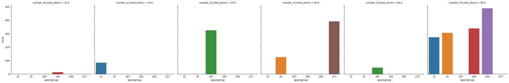

```python
sns.catplot(data=df_train, x='spacegroup', col='number_of_total_atoms', kind='count')

plt.show()
```

**`test.csv`**

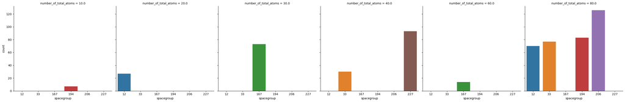

```python
sns.catplot(data=df_test, x='spacegroup', col='number_of_total_atoms', kind='count')

plt.show()
```

> Take-Home: The count plots are similar for both the training and testing datasets. Furthermore, there are certain crystals with only one combination of spacegroup and number of atoms (e.g., crystals with 10 atoms only belong to the spacegroup 194). It's relevant to note that the values of `number_of_total_atoms` with a larger number of different `spacegroup` values are 40 and 80 atoms per crystal.

#### Heatmap for the binarized number of atoms vs spacegroup on the `train.csv` dataset

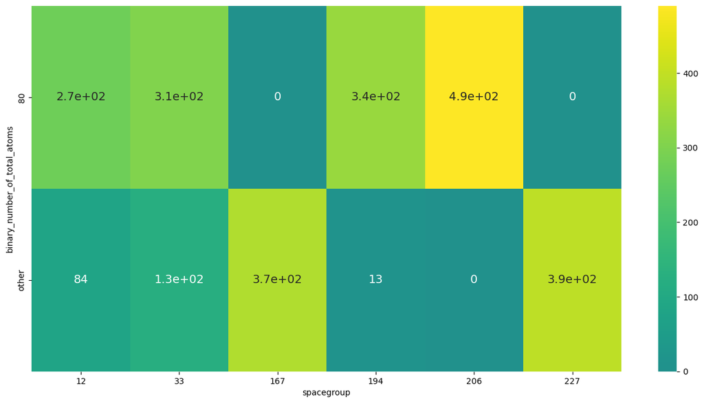

```python
fig,ax = plt.subplots(figsize=(16,8))

sns.heatmap(data=pd.crosstab( df_train.binary_number_of_total_atoms, df_train.spacegroup ),
            xticklabels=['12','33','167','194','206','227'],
            cmap='viridis',
            center=0,
            annot=True,
            annot_kws={'fontsize':14},
            ax=ax)

plt.show()
```

> Take-Home: The `binary_number_of_total_atoms` variable follows a similar trend than the `number_of_total_atoms`. Most of the observations are centered on the spacegroup 206 for the crystals with 80 atoms, whereas, for the other crystals, observations are mostly split between the spacegroups 167 and 227

## Distributions of Continous inputs

**Overall Take-Home:** The distributions once again are similar for both the training and test sets. Many continous variables have distributions heavily centered around certain values, which is no surprise given that many properties are strictly dependent on the spacegroup number (e.g., the lattice angles are determined by the spacegroup number and fixed around a value)

### Density plots using only the original inputs

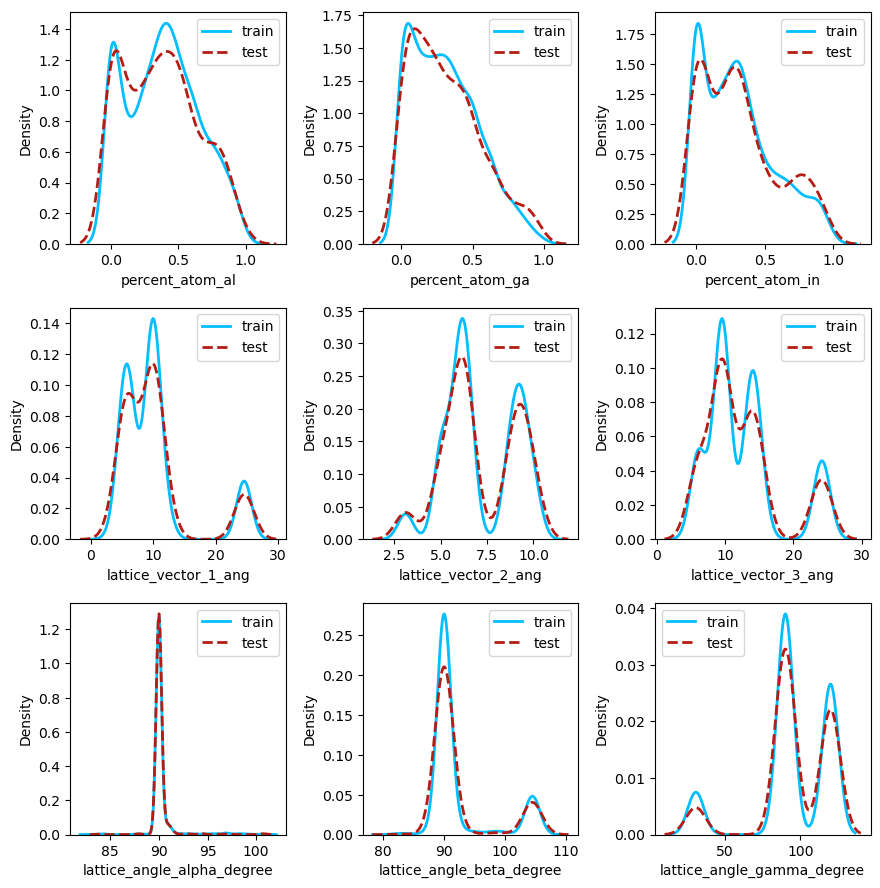

```python
fig, ax = plt.subplots(3,3,figsize=(9,9))
ax = ax.flatten()

for idx, var in enumerate(input_list):
    sns.kdeplot(data=df_train, x=var, ax=ax[idx], color=c_train, label='train', linewidth=2, common_norm=False, common_grid=False)
    sns.kdeplot(data=df_test, x=var, ax=ax[idx],linestyle='--', color=c_test, label='test', linewidth=2, common_norm=False, common_grid=False)
    ax[idx].legend()

plt.tight_layout()
plt.show()
```

> Take-Home: The distributions are similar for both the `train.csv` and `test.csv`. The distributions are not normal, as most inputs have theoretically fixed values

### Density plots using the preprocessed inputs

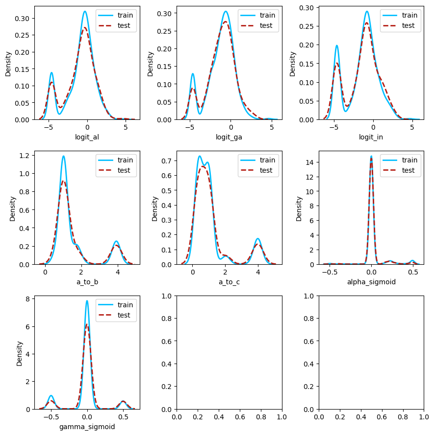

```python
fig, ax = plt.subplots(3,3,figsize=(9,9))
ax = ax.flatten()

for idx, var in enumerate(prepro_features_list):
    sns.kdeplot(data=prepro_df_train, x=var, ax=ax[idx], color=c_train, label='train', linewidth=2, common_norm=False, common_grid=False)
    sns.kdeplot(data=prepro_df_test, x=var, ax=ax[idx],linestyle='--', color=c_test, label='test', linewidth=2, common_norm=False, common_grid=False)
    ax[idx].legend()

plt.tight_layout()
plt.show()
```

> Take-Home: Similar as before, distributions between datasets are similar and not normal

## Distributions of continous inputs affected by categorical variables

### Original inputs

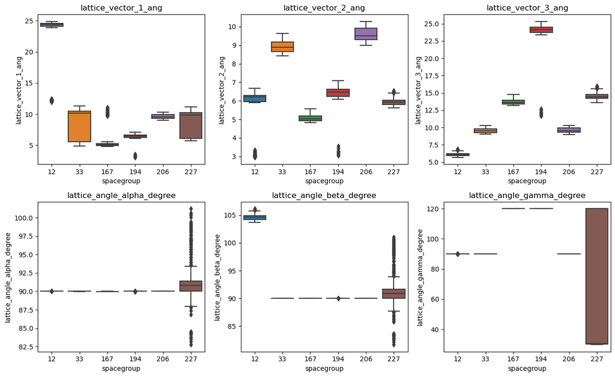

```python
fig,ax = plt.subplots(2,3,figsize=(13,8))
ax = ax.flatten()
for idx, var in enumerate(['lattice_vector_1_ang','lattice_vector_2_ang','lattice_vector_3_ang','lattice_angle_alpha_degree','lattice_angle_beta_degree','lattice_angle_gamma_degree']):
    sns.boxplot(data=df_train, y=var, x='spacegroup', ax=ax[idx]).set(title=var)

plt.tight_layout()
plt.show()
```

> Take-Home: As expected, the lattice angles and vectors vary with the spacegroup number (since many of them are pre-defined by the spacegroup id number). One relevant observation is that the angles vary the most for the spacegroup 227, which, in theory, should correspond to a cubic crystal with all its angles equal to 90 degrees

### Preprocessing inputs

sigmoids, a_to_b and a_to_c

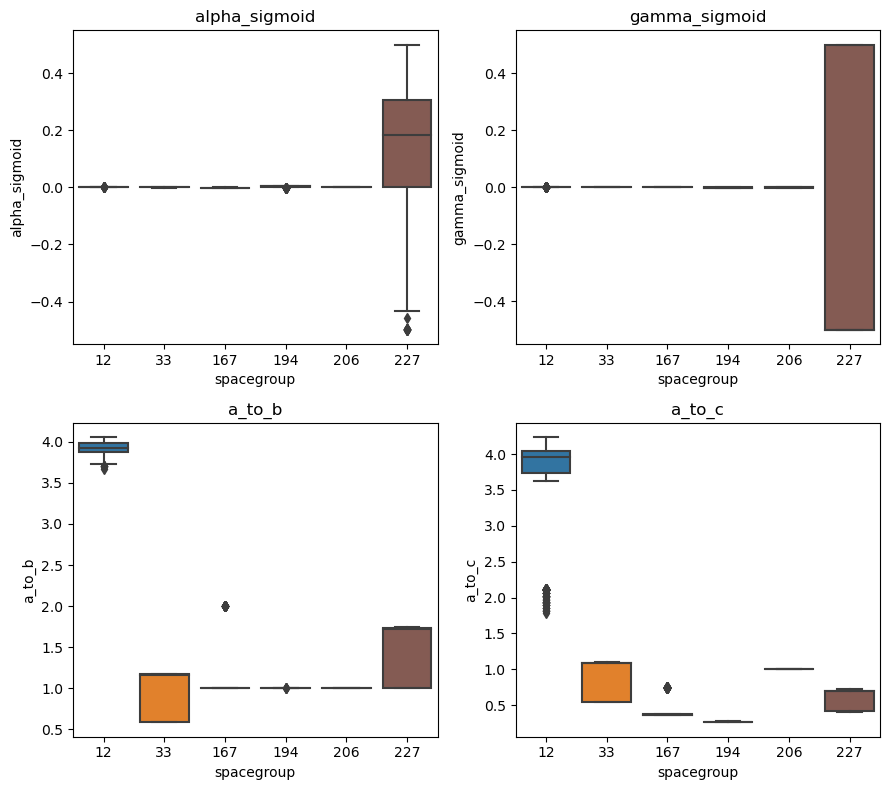

```python
fig,ax = plt.subplots(2,2,figsize=(9,8))
ax = ax.flatten()
for idx, var in enumerate(['alpha_sigmoid','gamma_sigmoid','a_to_b','a_to_c']):
    sns.boxplot(data=prepro_df_train, y=var, x='spacegroup', ax=ax[idx]).set(title=var)

plt.tight_layout()
plt.show()
```

> Take-Home: As expected, the variables `alpha_sigmoid` and `gamma_sigmoid` have the larges range for the spacegroup id 227. The ratios of lattice vectors have a similar range for the spacegroups 33 and 227

## Continous input to continous input relationships

### Original inputs (correlation plot)

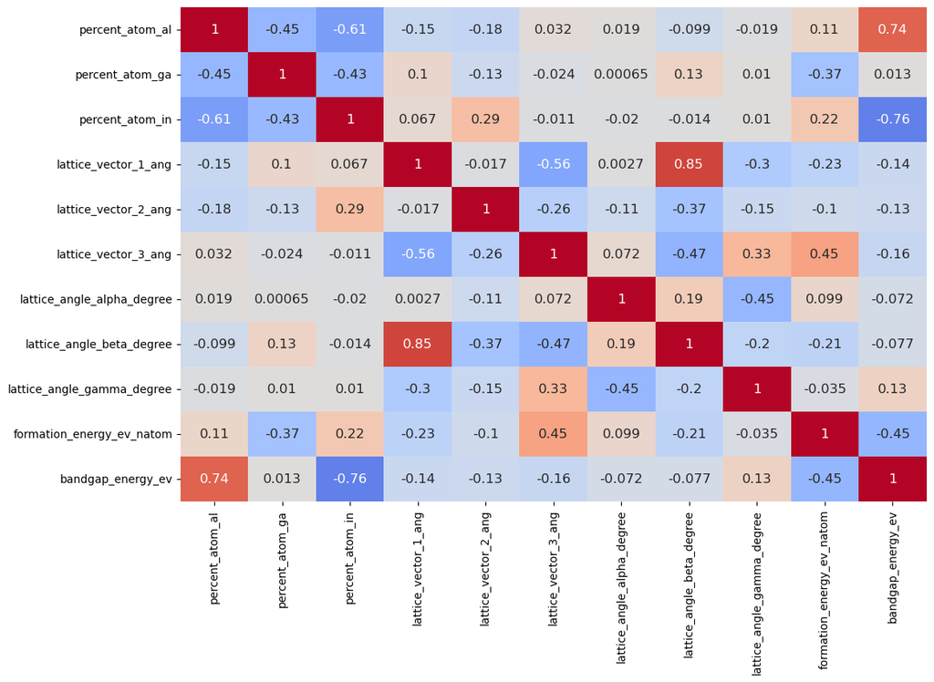

```python
fig, ax = plt.subplots(figsize=(12, 8))

sns.heatmap(df_train.loc[:,input_list+output_list].corr(),
            vmin=-1, vmax=1, center=0,
            cmap='coolwarm', cbar=False,
            annot=True, annot_kws={'size':12},
            ax=ax)

plt.show()
```

> Take-Home: There's correlation between input variables, as well as between outputs and inputs. Variable transformation with PCA might be convenient

### Original inputs (relevant relations)

Most of the relevant relations are evident when separating the plots according to the `spacegroup` numbers. Here I will show some of the most evident relations

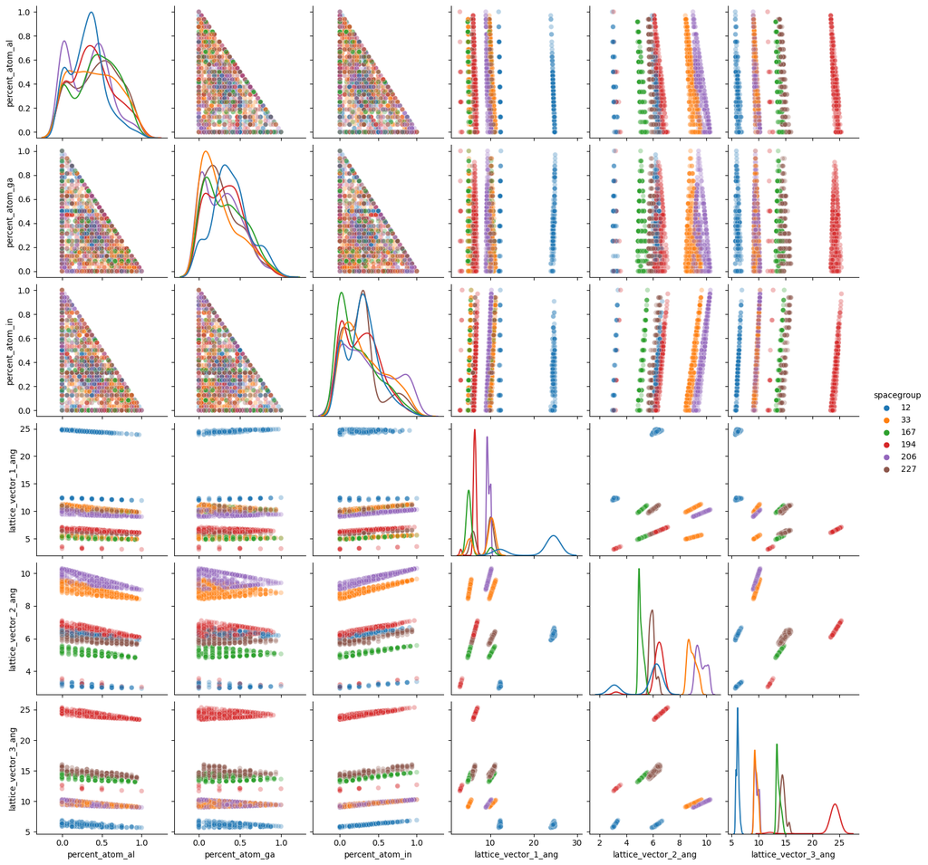

```python
sns.pairplot(data=df_train.loc[:,['percent_atom_al','percent_atom_ga','percent_atom_in','lattice_vector_1_ang','lattice_vector_2_ang','lattice_vector_3_ang']+['spacegroup']],
             hue='spacegroup',
             diag_kind='kde', diag_kws ={'common_norm' : False, 'fill':False},
             plot_kws={'alpha':0.3})
plt.show()
```

> Take-Home: Many relations appear only when filtering by spacegroup. Particularly, the percentages of Al and In seem to affect slightly the values of the lattice vectors.

### Preprocessing features (correlation plot)

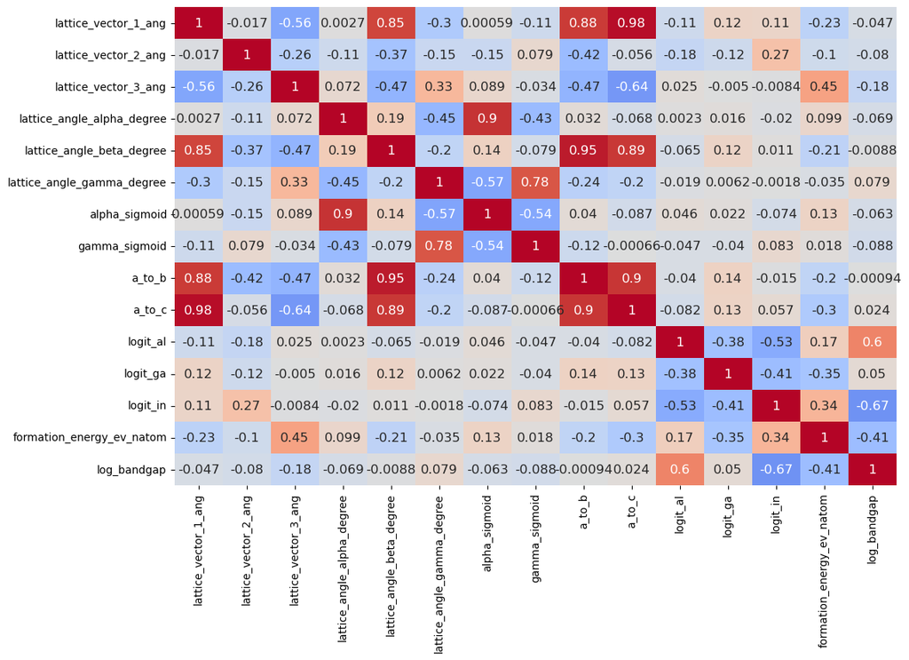

```python
fig, ax = plt.subplots(figsize=(12, 8))

sns.heatmap(prepro_df_train.loc[:,prepro_input_list+prepro_output_list].corr(),
            vmin=-1, vmax=1, center=0,
            cmap='coolwarm', cbar=False,
            annot=True, annot_kws={'size':12},
            ax=ax)

plt.show()
```

> Take-Home: Again, many variables are correlated with each other, which hints that using PCA might be advantageous

### Preprocessing features (relevant relations)

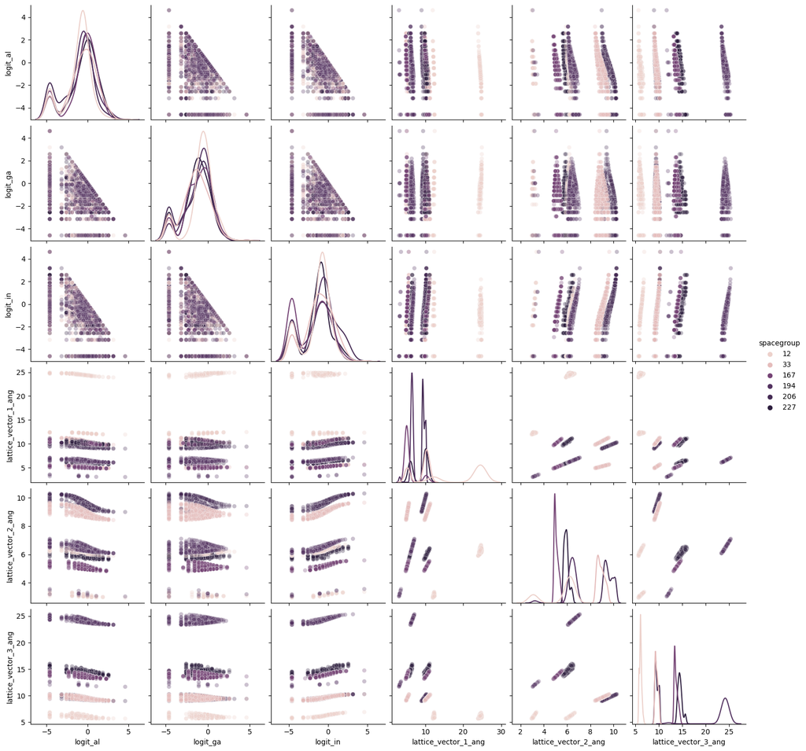

```python
sns.pairplot(data=prepro_df_train.loc[:,['logit_al','logit_ga','logit_in','lattice_vector_1_ang','lattice_vector_2_ang','lattice_vector_3_ang']+['spacegroup']],
             hue='spacegroup',
             diag_kind='kde', diag_kws ={'common_norm' : False, 'fill':False},
             plot_kws={'alpha':0.3})
plt.show()
```

> Take-Home: A similar behavior is observed, the lattice vectors depend on the logit-transformed percentages of Al, In and, in a lesser extent, Ga

## Distributions of outputs

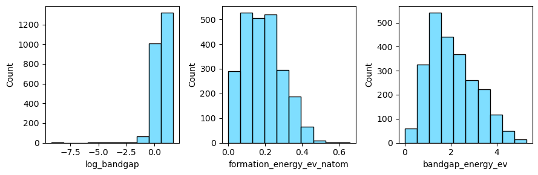

```python
fig, ax = plt.subplots(1,3,figsize=(9,3))
ax = ax.flatten()

for idx, var in enumerate(list(set(output_list+prepro_output_list))):
    sns.histplot(data=prepro_df_train, x=var, ax=ax[idx], color=c_train, bins=10, alpha=0.5)

plt.tight_layout()
plt.show()
```

## Output to categorical relationships

Bar and violin to show that the outputs depend mainly on spacegroup and number of atoms

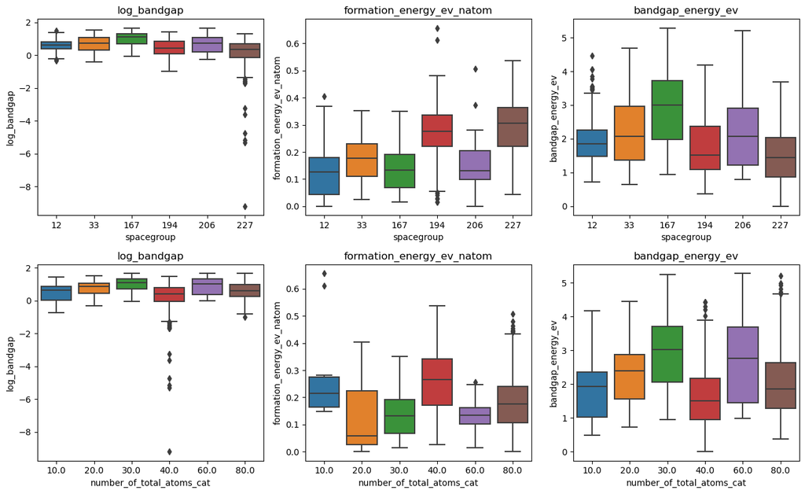

```python
fig,ax = plt.subplots(2,3,figsize=(13,8))
idx = 0
cat=['spacegroup','number_of_atoms']
for idx, var in enumerate(list(set(output_list+prepro_output_list))):
    sns.boxplot(data=prepro_df_train, y=var, x='spacegroup', ax=ax[0,idx]).set(title=var)
    sns.boxplot(data=prepro_df_train, y=var, x='number_of_total_atoms_cat', ax=ax[1,idx]).set(title=var)

plt.tight_layout()
plt.show()
```

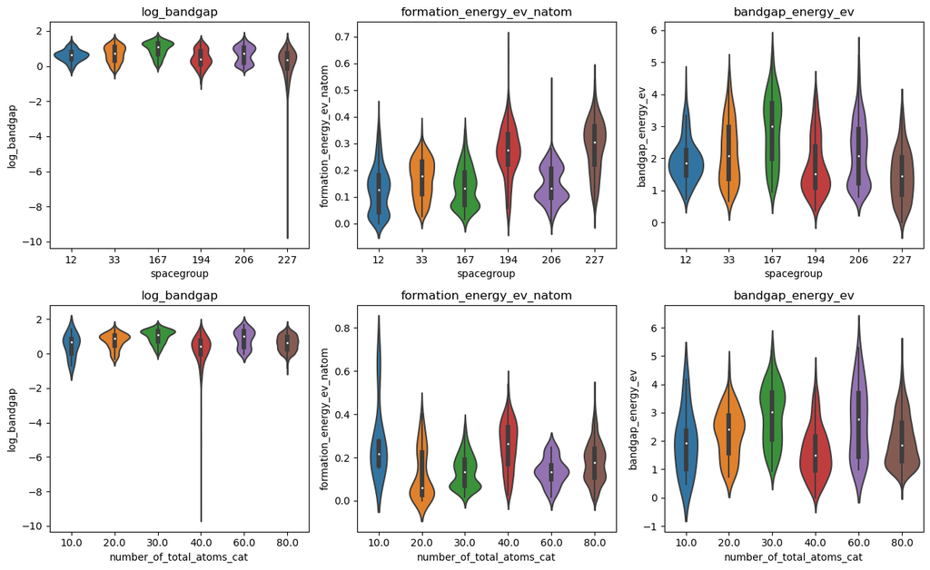

```python
fig,ax = plt.subplots(2,3,figsize=(13,8))
idx = 0
cat=['spacegroup','number_of_atoms']
for idx, var in enumerate(list(set(output_list+prepro_output_list))):
    sns.violinplot(data=prepro_df_train, y=var, x='spacegroup', ax=ax[0,idx]).set(title=var)
    sns.violinplot(data=prepro_df_train, y=var, x='number_of_total_atoms_cat', ax=ax[1,idx]).set(title=var)

plt.tight_layout()
plt.show()
```

> Take-Home: The outputs depend on the categoricals, as we can see on the boxplot. In particular, the `spacegroup` categorical seems like a reasonable choice since it is better distributed compared to the total number of atoms. On another hand, from the violin plots, it can be seen that the distributions are not uniform.

## Output to continous input relations

### Original inputs

Formation Energy

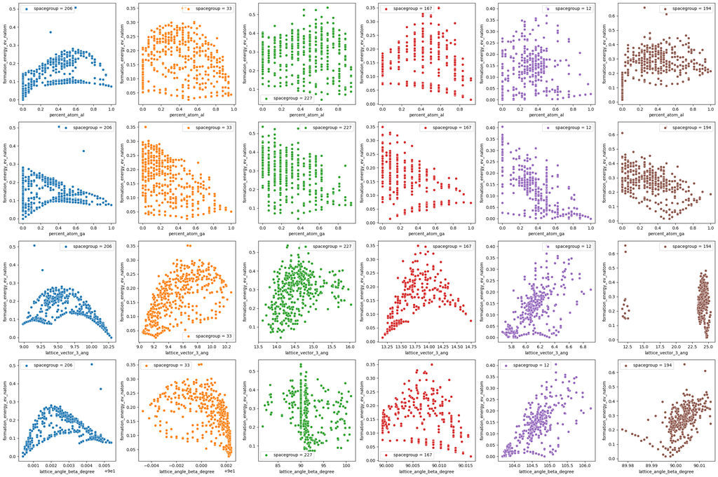

```python
row = len(['percent_atom_al','percent_atom_ga','lattice_vector_3_ang','lattice_angle_beta_degree'])
col = len(df_train.spacegroup.value_counts().index.to_list())

fig,ax = plt.subplots(row,col,
                      figsize=(4*col , 4*row))

colors = sns.color_palette("tab10", len(df_train.spacegroup.value_counts().index.to_list()))

for idx1, inp in enumerate(['percent_atom_al','percent_atom_ga','lattice_vector_3_ang','lattice_angle_beta_degree']):
    for idx2, spc in enumerate(df_train.spacegroup.value_counts().index.to_list()):
        sns.scatterplot(data=df_train.loc[df_train.loc[:,'spacegroup']==spc, :], x=inp, y='formation_energy_ev_natom', ax=ax[idx1,idx2], color=colors[idx2], label='spacegroup = '+str(spc))
        ax[idx1,idx2].legend()

plt.tight_layout()
plt.show()
```

> Take-Home: The formation energy doesn't exhibit clearly defined relations with the main inputs

Bandgap

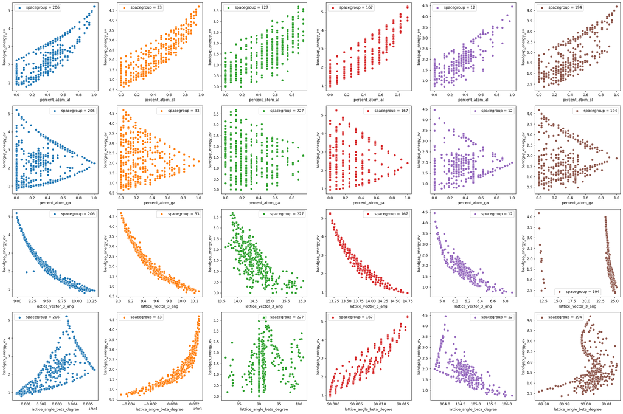

```python
row = len(['percent_atom_al','percent_atom_ga','lattice_vector_3_ang','lattice_angle_beta_degree'])
col = len(df_train.spacegroup.value_counts().index.to_list())

fig,ax = plt.subplots(row,col,
                      figsize=(4*col , 4*row))

colors = sns.color_palette("tab10", len(df_train.spacegroup.value_counts().index.to_list()))

for idx1, inp in enumerate(['percent_atom_al','percent_atom_ga','lattice_vector_3_ang','lattice_angle_beta_degree']):
    for idx2, spc in enumerate(df_train.spacegroup.value_counts().index.to_list()):
        sns.scatterplot(data=df_train.loc[df_train.loc[:,'spacegroup']==spc, :], x=inp, y='bandgap_energy_ev', ax=ax[idx1,idx2], color=colors[idx2], label='spacegroup = '+str(spc))
        ax[idx1,idx2].legend()

plt.tight_layout()
plt.show()
```

### Preprocessing inputs

Formation Energy

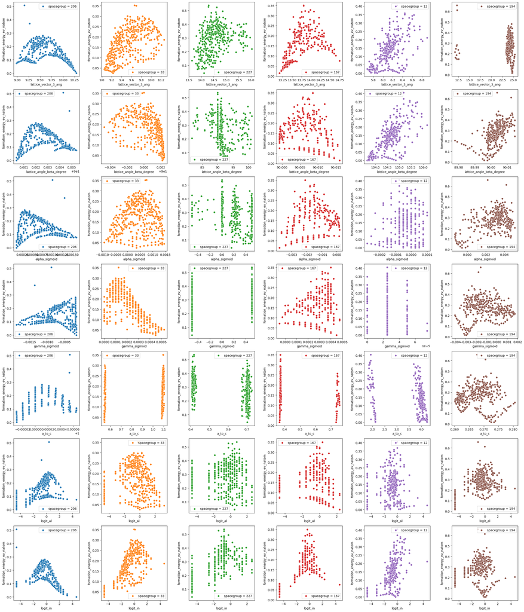

```python
row = len(['lattice_vector_3_ang','lattice_angle_beta_degree','alpha_sigmoid','gamma_sigmoid','a_to_c','logit_al','logit_in'])
col = len(prepro_df_train.spacegroup.value_counts().index.to_list())

fig,ax = plt.subplots(row,col,
                      figsize=(4*col , 4*row))

colors = sns.color_palette("tab10", len(prepro_df_train.spacegroup.value_counts().index.to_list()))

for idx1, inp in enumerate(['lattice_vector_3_ang','lattice_angle_beta_degree','alpha_sigmoid','gamma_sigmoid','a_to_c','logit_al','logit_in']):
    for idx2, spc in enumerate(prepro_df_train.spacegroup.value_counts().index.to_list()):
        sns.scatterplot(data=prepro_df_train.loc[prepro_df_train.loc[:,'spacegroup']==spc, :], x=inp, y='formation_energy_ev_natom', ax=ax[idx1,idx2], color=colors[idx2], label='spacegroup = '+str(spc))
        ax[idx1,idx2].legend()

plt.tight_layout()
plt.show()
```

> Take-Home: Once again, we note the difficulty of extracting clear relations within the formation energy and the inputs (both the original and the preprocessed inputs). This likely suggests the need of using non-linear models

log bandgap

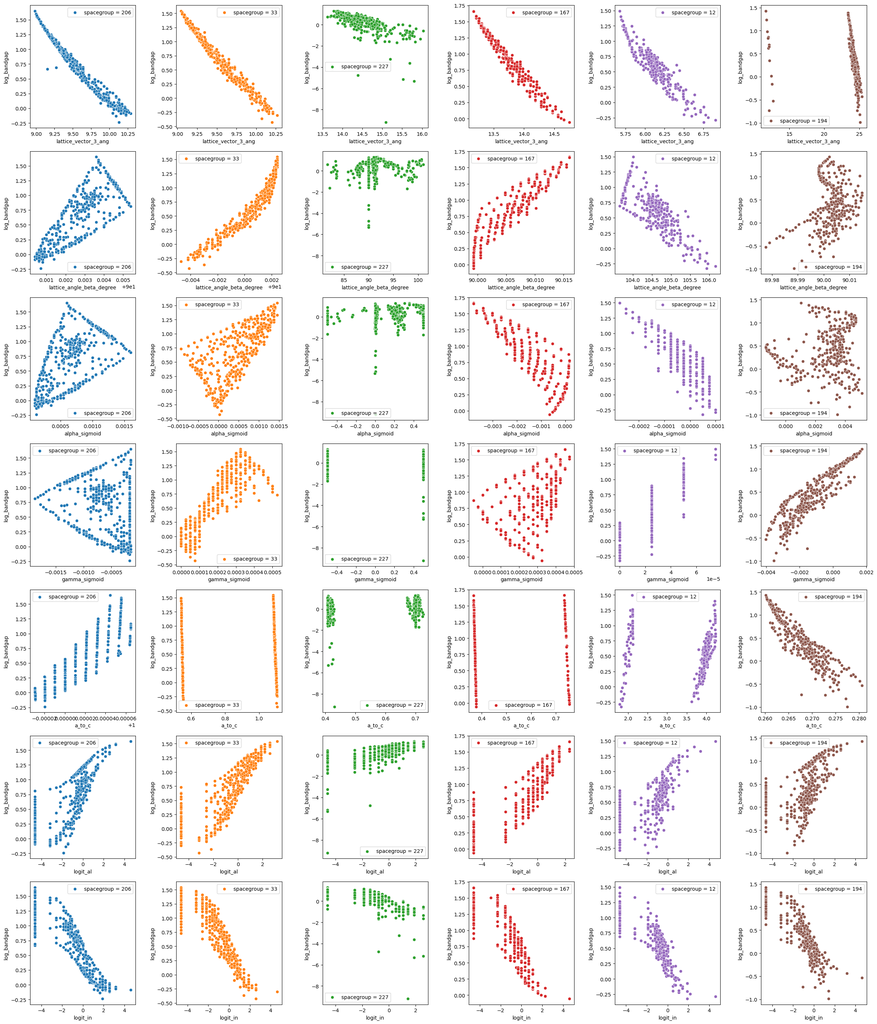

```python
row = len(['lattice_vector_3_ang','lattice_angle_beta_degree','alpha_sigmoid','gamma_sigmoid','a_to_c','logit_al','logit_in'])
col = len(prepro_df_train.spacegroup.value_counts().index.to_list())

fig,ax = plt.subplots(row,col,
                      figsize=(4*col , 4*row))

colors = sns.color_palette("tab10", len(prepro_df_train.spacegroup.value_counts().index.to_list()))

for idx1, inp in enumerate(['lattice_vector_3_ang','lattice_angle_beta_degree','alpha_sigmoid','gamma_sigmoid','a_to_c','logit_al','logit_in']):
    for idx2, spc in enumerate(prepro_df_train.spacegroup.value_counts().index.to_list()):
        sns.scatterplot(data=prepro_df_train.loc[prepro_df_train.loc[:,'spacegroup']==spc, :], x=inp, y='log_bandgap', ax=ax[idx1,idx2], color=colors[idx2], label='spacegroup = '+str(spc))
        ax[idx1,idx2].legend()

plt.tight_layout()
plt.show()
```